# Outside Context Memory

> This notebook focuses on context memory outside the rooms. The hit rate data was corrected by subtracting false alarm rate from the original hit rate *for each room*. In those cases when the corrected hit rate was negative (the hit rate was lower than the false alarm rate), the corrected hit rate was forced to be 0. Note that the corrected hit rate is meaningful only when it was calculated as a mean.

# 1 Overview of the data

The rooms were separated into *Familiar* and *Novel* groups. Participants explored the *Familiar* group at the beginning of the experiment. In the encoding task, they visisted both *Familiar* and *Novel* groups. Their context memory (i.e., in which room they saw the item) was tested in the memory test the next day of the encoding task. **Novelty benefits** on the context memory are examined by comparing the memory performance between the *Familiar* and *Novel* groups.

Participants were also asked to rate how curious they felt about the room. The higher the rating is means they felt more curious about the room. Context memory as a function of curiosity rating was also examined for **curiosity benefits**.

Questionnaires on personal traits regarding curiosity were also administered to participants before the encoding task (i.e., PC and EC). Scores on these questionnaires might be able to predict the context memory or its relationship with curiosity rating.

In the encoding task, there were 6 objects outside each room. It is possbile that the context memory for the object to some extent depends on the order in which the object was seen. For example, it may be easier to remember where the first and last objects were seen as compared to those in the middle. Particularly, if the participant became more curious when getting closer to the room, then one would expect that the performance increases as a function of item order.

# 2 Individual performance

## 2.1 An overview of individual context memory performance as a function of room.

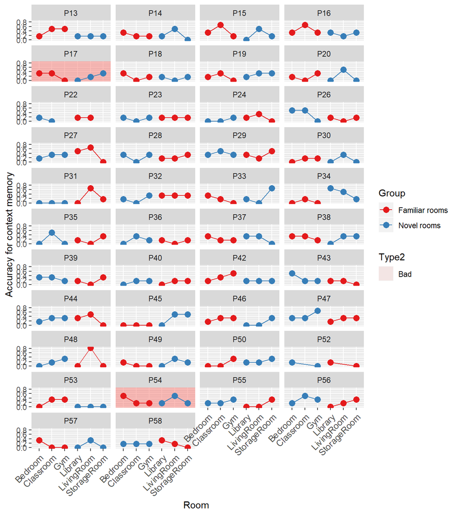

Figure 1. Mean accuracy for context memory respectively for each room and each individual participant.

# 3 Novelty Benefits

We predicted that the context memory should be better for the *novel* rooms than for the *familiar* rooms.

## 3.1 Compare mean accuracy between *novel* and *familiar* rooms

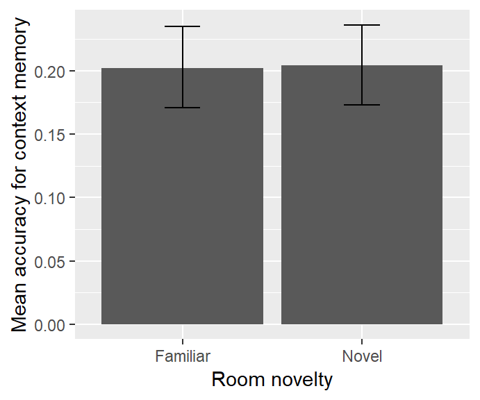

Figure 2. Mean accuracy for context memory respectively for Familiar and Novel rooms.

```
##
##  Paired t-test
##
## data:  MeanCorrContextAccuracy by Group
## t = -0.08961, df = 39, p-value = 0.9291
## alternative hypothesis: true difference in means is not equal to 0
## 95 percent confidence interval:
##  -0.04910847  0.04494181
## sample estimates:
## mean of the differences
##            -0.002083333
```

There was no difference in average recollection performance for source memory between the *Familiar* and *Novel* rooms.

## 3.2 Context memory as a function of item order

### 3.2.1 Visualise the data

#### 3.2.1.1 Nonlinear

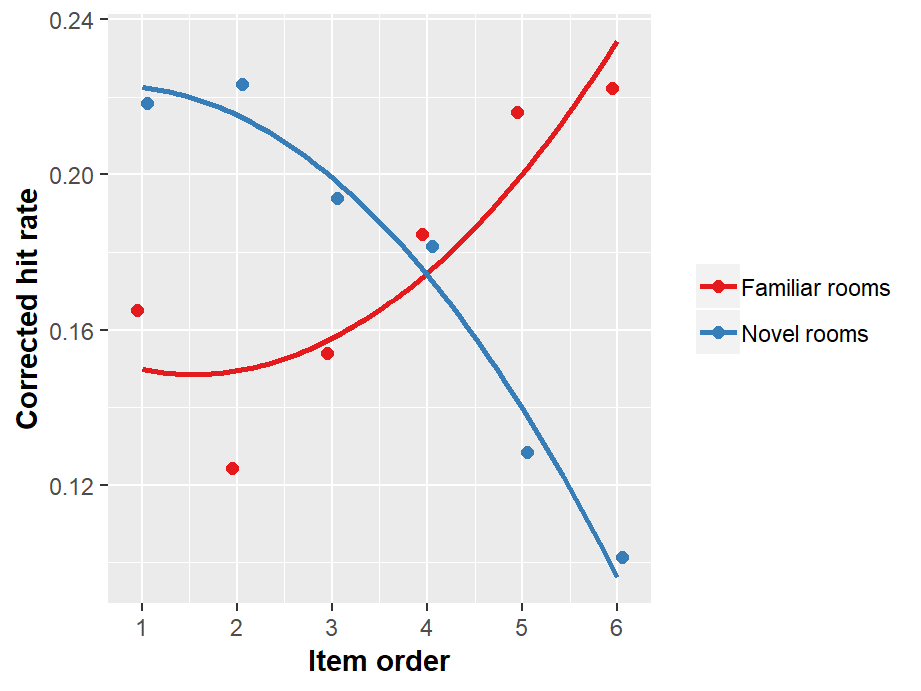

Figure 3. Mean accuracy of context memory for items at each order (i.e., 1st, 2nd, 3rd, etc), respectively for familiar and novel rooms.

#### 3.2.1.2 Linear

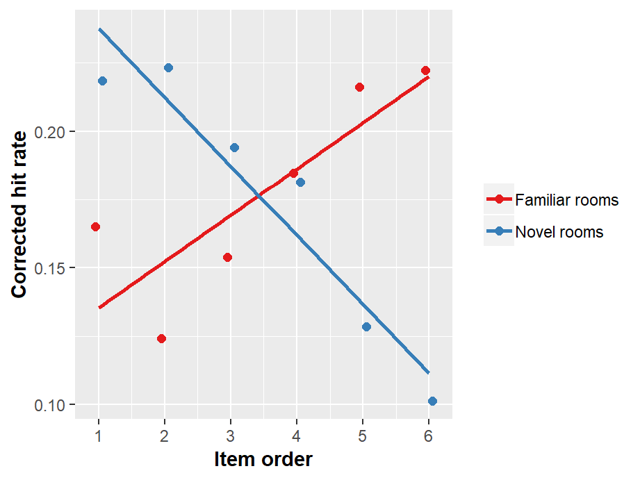

Figure 4. Mean accuracy of context memory for items at each order (i.e., 1st, 2nd, 3rd, etc), respectively for familiar and novel rooms.

### 3.2.2 Examing the relationship using mixed models.

Build models with corrected hit rate as $y$ and then examine effects of item order and novelty by comparing the models.

- `baseline.context` is the model with only an intercept.
- `order.model.linear.1` is the model with $\small ItemOrder$ included, showing the effects of item order.
- `order.model.linear.2` is the model allowing the slope (i.e., relationship between context memory and item order) varying across participants.
- `order.model.quad.1` and `order.model.quad.2` repectively included $\small ItemOrder^2$ and related random effects.
- `novelty.model.1` is the model with $\small Group$ (i.e., *familiar* and *novel* rooms) included, examining the effects of novelty of the rooms on the intercept (i.e., mean context memory accuracy at the 1st order or overall if no difference in slope).
- `novelty.model.2` is the model with interaction between $\small Group$ and $\small ItemOrder$ included, examining the effects of novelty on how context memory accuracy changes as a function of item order.
- `novelty.model.3` included interaction between $\small Group$ and $\small ItemOrder^2$ for inestigating whether the pattern changes between *familiar* and *novel* groups.

**Note: here I only examined the linear relationship.**

```
##                      Model df       AIC       BIC   logLik   Test
## baseline.context         1  4 -104.6746 -87.97947 56.33731
## order.model.linear.1     2  5 -103.2023 -82.33337 56.60115 1 vs 2
## novelty.model.1          3  6 -101.2289 -76.18623 56.61447 2 vs 3
## novelty.model.2          4  7 -113.1370 -83.92047 63.56849 3 vs 4
##                        L.Ratio p-value
## baseline.context
## order.model.linear.1  0.527689  0.4676
## novelty.model.1       0.026646  0.8703
## novelty.model.2      13.908022  0.0002
```

There was a significant interaction between *Novelty* and *Item order*, ${\chi}^2$(1)=13.91, *p* < 0.01.

#### 3.2.2.1 Parameter estimation for the optimal model

```
##                          Value  Std.Error  DF   t-value      p-value
## (Intercept)         0.23759921 0.02462528 398  9.648591 6.209575e-20
## ItemOrderCt        -0.02522487 0.00795942 398 -3.169184 1.646813e-03
## Group1             -0.10218915 0.03443568  39 -2.967537 5.107988e-03
## ItemOrderCt:Group1  0.04215344 0.01125632 398  3.744869 2.071196e-04
```

From the parameters of the complete model: * for *Novel* rooms, the performance decreased significantly against the item order, *b* = -0.025, *t*(398) = -3.17, *p* < 0.01. * For the first item that was saw on the pathway, the recollection was significantly worse for the *Familiar* rooms than for the *Novel* rooms, *b* = -0.10, *t*(39) = -2.97, *p* < 0.01. * The change rate of recollection against item order was significantly larger (more positive) for the *Familiar* rooms than the *Novel* rooms, *b* = 0.042, *t*(398) = 3.74, *p* < 0.001.

### 3.2.3 Collapse the order

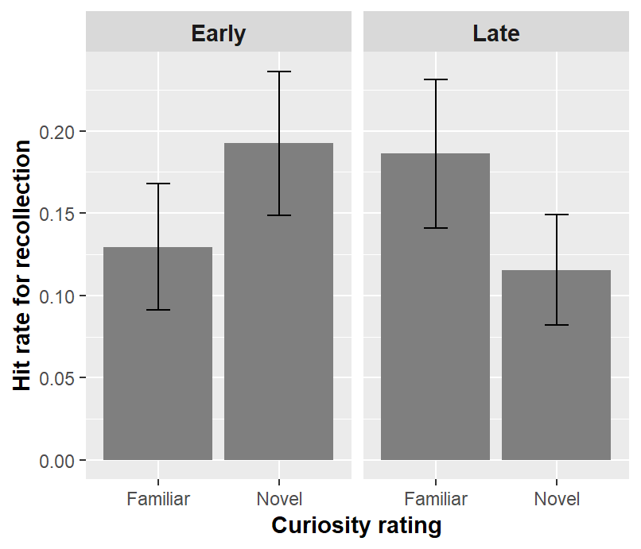

#### 3.2.3.1 Stats on it

##### 3.2.3.1.1 Using `lme`

```
##                  Model df       AIC       BIC   logLik   Test   L.Ratio
## baseline             1  5 -192.3302 -176.9544 101.1651
## noveltyModel         2  6 -190.3650 -171.9140 101.1825 1 vs 2  0.034791
## orderModel           3  7 -188.6471 -167.1209 101.3236 2 vs 3  0.282092
## interactionModel     4  8 -199.8496 -175.2483 107.9248 3 vs 4 13.202525
##                  p-value
## baseline
## noveltyModel      0.8520
## orderModel        0.5953
## interactionModel  0.0003
```

In line with the analysis above, there was a significant interaction between *Novelty* and *ItemOrder* (Early vs. Late), ${\chi}^2$(1)=13.20, *p* < 0.001.

```r
summary(interactionModel)$tTable
```

```
##                                Value  Std.Error DF   t-value      p-value
## (Intercept)               0.19236111 0.01995130 78  9.641535 6.183576e-15
## Group1                   -0.06277778 0.02772743 39 -2.264104 2.920564e-02
## ItemOrderTypeLate        -0.07685185 0.02521022 78 -3.048441 3.140116e-03
## Group1:ItemOrderTypeLate  0.13337963 0.03565263 78  3.741088 3.481994e-04
```

##### 3.2.3.1.2 Simple effects in “Early”

```r
t.test(CorrContextAccuracy ~ Group, data = Curiosity.Recall.Old.Order.Novelty[!SubjectNo %in% bad.ps.less.strict & ItemOrderType == "Early"], paired = T)
```

```
##
##  Paired t-test
##
## data:  CorrContextAccuracy by Group
## t = -1.9384, df = 39, p-value = 0.05984
## alternative hypothesis: true difference in means is not equal to 0
## 95 percent confidence interval:
##  -0.128285921  0.002730365
## sample estimates:
## mean of the differences
##             -0.06277778
```

Looks a bit different from the parameter tests in the model above, but not much. It may be due to the way the data was included.

##### 3.2.3.1.3 Simple effects in “Late”

```r
t.test(CorrContextAccuracy ~ Group, data = Curiosity.Recall.Old.Order.Novelty[!SubjectNo %in% bad.ps.less.strict & ItemOrderType == "Late"], paired = T)
```

```
##
##  Paired t-test
##
## data:  CorrContextAccuracy by Group
## t = 3.0605, df = 39, p-value = 0.003987
## alternative hypothesis: true difference in means is not equal to 0
## 95 percent confidence interval:
##  0.02394055 0.11726315
## sample estimates:
## mean of the differences
##              0.07060185
```

# 4 Curiosity Benefits

Here I checked how corrected hit rate changes as a function of curiosity rating. We hypothesised that the more curiosity the participant felt about the room (higher ratings) the better the context memory.

## 4.1 Mean accuracy of context memory as a function of curiosity rating

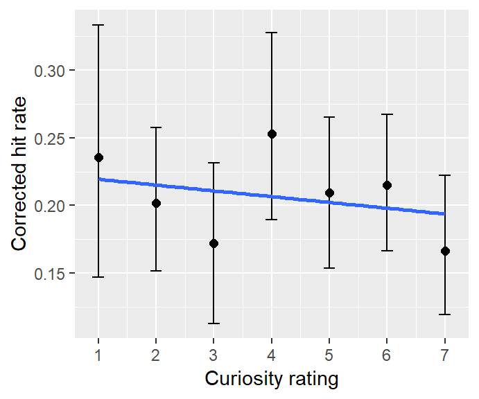

Figure 5. Mean accuracy for context memory as a function of curiosity rating.

It appears to be an overall negative correction between curiosity rating and source memory performance.

### 4.1.1 Testing the relationship between mean accuracy of context memory and curiosity rating

Build models with context memory accuracy as $y$ and cexamine effects of curiosity rating by including it into the model and then comparing the model fits.

- `baseline.rating` is the model with only an intercept, showing no change in context memory as a function of curiosity rating.
- `rating.intercept` is the model with $\small CuriosityRating$ included, showing the effects of curiosity rating.
- `rating.slope` is the model allowing the slope (i.e., relationship between context memory and curiosity rating) varying across participants.

```
##                  Model df       AIC       BIC   logLik   Test   L.Ratio
## baseline.rating      1  3 -138.5264 -128.1349 72.26317
## rating.intercept     2  4 -137.0160 -123.1607 72.50799 1 vs 2 0.4896329
## rating.slope         3  6 -133.0124 -112.2294 72.50620 2 vs 3 0.0035742
##                  p-value
## baseline.rating
## rating.intercept  0.4841
## rating.slope      0.9982
```

Not significant.

### 4.1.2 **Using normalised curiosity ratings.**

```
##                  Model df       AIC       BIC   logLik   Test    L.Ratio
## baseline.rating      1  3 -138.5264 -128.1349 72.26317
## rating.intercept     2  4 -136.8353 -122.9800 72.41767 1 vs 2 0.30899665
## rating.slope         3  6 -132.8342 -112.0513 72.41712 2 vs 3 0.00109403
##                  p-value
## baseline.rating
## rating.intercept  0.5783
## rating.slope      0.9995
```

Again, not significant.

## 4.2 Does the relationship with curiosity rating depend on item order?

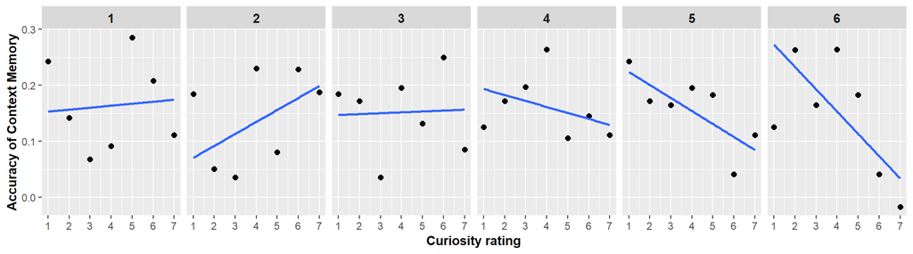

Figure 6. Mean accuracy across participants for context memory as a function of curiosity rating for each order at which the item was seen (I.e., 1st, 2nd, 3rd, etc.).

It seems that the relationship with the curiosity ratings changes as a function of item order - it becomes more negative with later item.

### 4.2.1 Testing the effect of item order

Build models with corrected hit rate as $y$ and examine effects of curioity rating and item order by comparing the models.

- `item.model.linear.1` is the model with $\small ItemOrder$ included (in addition to $\small CuriosityRating$), showing the effects of item order.
- `item.model.linear.2` is the model allowing the slope (i.e., relationship between context memory and item order) varying across participants.
- `item.model.linear.3` is the model with the interaction between $\small ItemOrders$ and $\small CuriosityRating$ included.
- `item.model.quad.1` and `item.model.quad.2` repectively included $\small ItemOrder^2$ and related random effects.
- `item.model.quad.3` included interaction between $\small ItemOrder^2$ and $\small CuriosityRating$ for inestigating whether the pattern changes as a function of *curiosity rating*.

```r
baseline.context <- lme(CorrContextAccuracy ~ 1, random = ~ 1|SubjectNo, data = Curiosity.Recall.Old[!SubjectNo %in% bad.ps.less.strict], method = "ML", control = list(msMaxIter = 500, opt = "optim", msVerbose=FALSE), na.action = na.exclude)

rating.intercept <- update(baseline.context, .~. + CuriosityRatingCt)
rating.slope     <- update(rating.intercept, random = ~ 1 + CuriosityRatingCt | SubjectNo)

item.model.linear.1     <- update(rating.slope, .~. + ItemOrderCt)
# item.model.linear.2     <- update(item.model.linear.1, random = list(~1+CuriosityRating|SubjectNo, ~1+ItemOrder|SubjectNo)) # Excluded because very little contribution to model fit improvement.
item.model.linear.3     <- update(item.model.linear.1, .~. + ItemOrderCt : CuriosityRatingCt)

# item.model.quad.1       <- update(item.model.linear.3, .~. + I(ItemOrder^2))
# item.model.quad.2       <- update(item.model.quad.1,   random = list(~1+CuriosityRating|SubjectNo, ~1+ItemOrder+I(ItemOrder^2)|SubjectNo)) # excluding this model because singularity issue (perhaps the model was getting too complex to be calculated)
# item.model.quad.3       <- update(item.model.quad.1,   .~. + I(ItemOrder^2) : CuriosityRating)

anova(baseline.context, rating.intercept, rating.slope, item.model.linear.1, item.model.linear.3)
```

```
##                     Model df      AIC      BIC    logLik   Test  L.Ratio
## baseline.context        1  3 1484.371 1500.138 -739.1856
## rating.intercept        2  4 1484.491 1505.513 -738.2455 1 vs 2 1.880130
## rating.slope            3  6 1488.480 1520.014 -738.2400 2 vs 3 0.011103
## item.model.linear.1     4  7 1490.056 1526.845 -738.0281 3 vs 4 0.423741
## item.model.linear.3     5  8 1482.318 1524.362 -733.1588 4 vs 5 9.738645
##                     p-value
## baseline.context
## rating.intercept     0.1703
## rating.slope         0.9945
## item.model.linear.1  0.5151
## item.model.linear.3  0.0018
```

Interaction was significant, ${\chi}^2$(1) = 9.73, *p* < 0.01.

#### 4.2.1.1 Parameter estimation for the optimal model

```r
summary(item.model.linear.3)$tTable
```

```
##                                     Value   Std.Error   DF   t-value
## (Intercept)                    0.09811144 0.039957703 1373  2.455382
## CuriosityRatingCt              0.01796557 0.010143674 1373  1.771111
## ItemOrderCt                    0.03153154 0.013051729 1373  2.415890
## CuriosityRatingCt:ItemOrderCt -0.01036068 0.003320593 1373 -3.120129
##                                   p-value
## (Intercept)                   0.014196717
## CuriosityRatingCt             0.076764115
## ItemOrderCt                   0.015826625
## CuriosityRatingCt:ItemOrderCt 0.001845365
```

For the first item on the pathway, there was a marginally significant correlation between source memory and curiosity ratings, *b* = 0.018, *t* = 1.77, *p* = 0.077.

The correlation got more negative as the distance between the item and room decreased, *b* = -0.01, *t* = -3.12, *p* < 0.01.

### 4.2.2 Collapse the order and curiosity rating

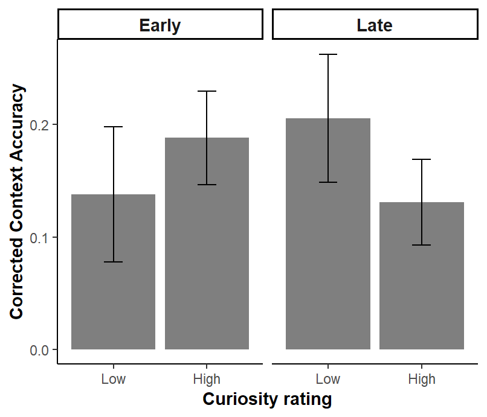

Figure 7. Mean hit rate as a function of item order (Early vs. Late) and curiosity (Low vs. High).

#### 4.2.2.1 Stats on it

```
##                  Model df       AIC       BIC   logLik   Test  L.Ratio
## baseline             1  5 -138.7852 -123.6658 74.39259
## curiosityModel       2  6 -136.9799 -118.8366 74.48993 1 vs 2 0.194686
## orderModel           3  7 -134.9870 -113.8199 74.49351 2 vs 3 0.007173
## interactionModel     4  8 -142.1971 -118.0061 79.09856 3 vs 4 9.210089
##                  p-value
## baseline
## curiosityModel    0.6590
## orderModel        0.9325
## interactionModel  0.0024
```

A significant interaction, ${\chi}^2$(1) = 9.21, *p* < 0.01.

```r
summary(interactionModel)$tTable
```

```
##                                                 Value  Std.Error DF
## (Intercept)                                0.13737633 0.02491775 74
## CuriosityRatingTypeHigh                    0.05072552 0.03349135 35
## ItemOrderTypeLate                          0.06743827 0.02930643 74
## CuriosityRatingTypeHigh:ItemOrderTypeLate -0.12472994 0.04039612 74
##                                             t-value      p-value
## (Intercept)                                5.513192 4.911431e-07
## CuriosityRatingTypeHigh                    1.514586 1.388569e-01
## ItemOrderTypeLate                          2.301143 2.420142e-02
## CuriosityRatingTypeHigh:ItemOrderTypeLate -3.087671 2.839347e-03
```

For the early items, the recollection was higer for high curiosity, but not significant, *P* = 0.14.

##### 4.2.2.1.1 Simple effects in “Early”

```r
# remove those with single curiosity ratings
temp.table <- as.data.frame(with(Curiosity.Recall.Old.Order.CuriosityType, table( SubjectNo, CuriosityRatingType)))
temp.table <- data.table(temp.table)
single.sbjs <- as.character(temp.table[CuriosityRatingType == "Low" & Freq < 2]$SubjectNo)

t.test(CorrContextAccuracy ~ CuriosityRatingType, data = Curiosity.Recall.Old.Order.CuriosityType[!SubjectNo %in% c(bad.ps.less.strict, single.sbjs) & ItemOrderType == "Early"], paired = T)
```

```
##
##  Paired t-test
##
## data:  CorrContextAccuracy by CuriosityRatingType
## t = -1.5058, df = 35, p-value = 0.1411
## alternative hypothesis: true difference in means is not equal to 0
## 95 percent confidence interval:
##  -0.13909385  0.02062677
## sample estimates:
## mean of the differences
##             -0.05923354
```

##### 4.2.2.1.2 Simple effects in “Late”

```r
t.test(CorrContextAccuracy ~ CuriosityRatingType, data = Curiosity.Recall.Old.Order.CuriosityType[!SubjectNo %in% c(bad.ps.less.strict, single.sbjs) & ItemOrderType == "Late"], paired = T)
```

```
##
##  Paired t-test
##
## data:  CorrContextAccuracy by CuriosityRatingType
## t = 2.2043, df = 35, p-value = 0.03417
## alternative hypothesis: true difference in means is not equal to 0
## 95 percent confidence interval:
##  0.005495574 0.133599076
## sample estimates:
## mean of the differences
##              0.06954733
```

However, for the late items, the recollection was better for *low* curiosity significantly, *p* = 0.034.

#### 4.2.2.2 Linear trend respectivley for High and Low curiosity groups

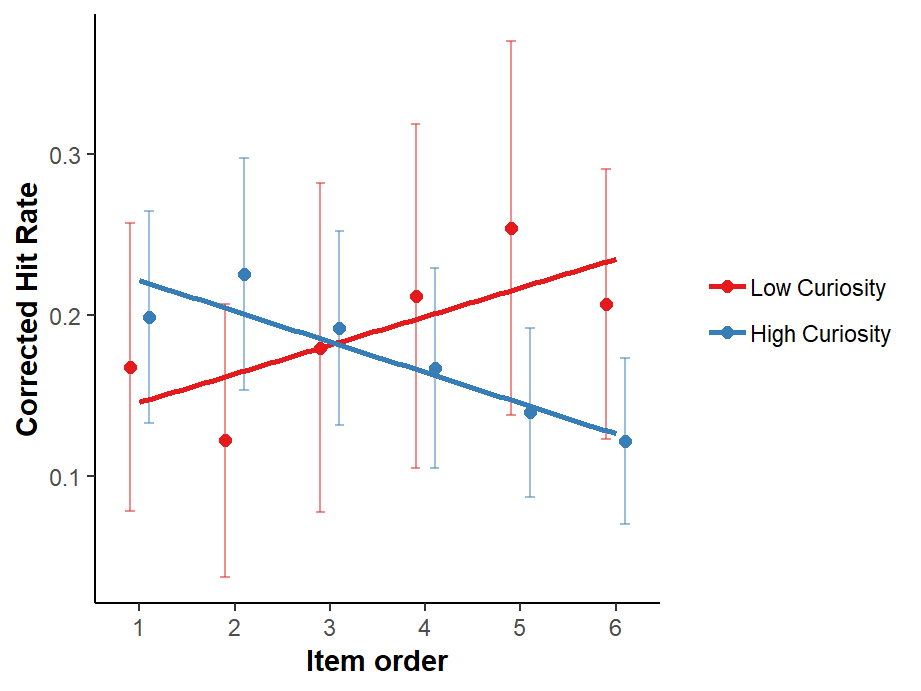

```r
Curiosity.Recall.Old.CuriosityType$ItemOrderCt <- Curiosity.Recall.Old.CuriosityType$ItemOrder - 1

baseline <- lme(CorrContextAccuracy ~ 1, random = ~ 1|SubjectNo/CuriosityRatingType, data = Curiosity.Recall.Old.CuriosityType[!SubjectNo %in% bad.ps.less.strict], method = "ML", control = list(msMaxIter = 500, opt = "optim", msVerbose=FALSE), na.action = na.exclude)

orderModel.linear.1   <- update(baseline,              .~. + ItemOrderCt)
orderModel.linear.2   <- update(orderModel.linear.1,   random = ~ 1 + ItemOrderCt|SubjectNo/CuriosityRatingType)

curiosityModel        <- update(orderModel.linear.2,   .~. + CuriosityRatingType)
curiosityModel.linear <- update(curiosityModel,        .~. + CuriosityRatingType : ItemOrderCt)

anova(baseline, orderModel.linear.1, orderModel.linear.2, curiosityModel, curiosityModel.linear)
```

```
##                       Model df       AIC      BIC   logLik   Test  L.Ratio
## baseline                  1  4  3.743872 20.23384 2.128064
## orderModel.linear.1       2  5  5.681830 26.29429 2.159085 1 vs 2 0.062042
## orderModel.linear.2       3  9 11.485777 48.58821 3.257112 2 vs 3 2.196053
## curiosityModel            4 10 12.457844 53.68277 3.771078 3 vs 4 1.027932
## curiosityModel.linear     5 11  6.533816 51.88124 7.733092 4 vs 5 7.924029
##                       p-value
## baseline
## orderModel.linear.1    0.8033
## orderModel.linear.2    0.6998
## curiosityModel         0.3106
## curiosityModel.linear  0.0049
```

Significant interaction, *p* < 0.01.

```r
summary(curiosityModel.linear)
```

```
## Linear mixed-effects model fit by maximum likelihood
##  Data: Curiosity.Recall.Old.CuriosityType[!SubjectNo %in% bad.ps.less.strict]
##        AIC      BIC   logLik
##   6.533816 51.88124 7.733092
##
## Random effects:
##  Formula: ~1 + ItemOrderCt | SubjectNo
##  Structure: General positive-definite, Log-Cholesky parametrization
##             StdDev       Corr
## (Intercept) 2.790891e-03 (Intr)
## ItemOrderCt 1.165522e-15 0
##
##  Formula: ~1 + ItemOrderCt | CuriosityRatingType %in% SubjectNo
##  Structure: General positive-definite, Log-Cholesky parametrization
##             StdDev     Corr
## (Intercept) 0.10917289 (Intr)
## ItemOrderCt 0.01507529 -0.956
## Residual    0.22736597
##
## Fixed effects: CorrContextAccuracy ~ ItemOrderCt + CuriosityRatingType + ItemOrderCt:CuriosityRatingType
##                                           Value  Std.Error  DF   t-value
## (Intercept)                          0.14578569 0.03306146 378  4.409536
## ItemOrderCt                          0.01782113 0.00944198 378  1.887437
## CuriosityRatingTypeHigh              0.07594711 0.04556777  35  1.666685
## ItemOrderCt:CuriosityRatingTypeHigh -0.03687537 0.01301487 378 -2.833326
##                                     p-value
## (Intercept)                          0.0000
## ItemOrderCt                          0.0599
## CuriosityRatingTypeHigh              0.1045
## ItemOrderCt:CuriosityRatingTypeHigh  0.0049
##  Correlation:
##                                     (Intr) ItmOrC CrsRTH
## ItemOrderCt                         -0.804
## CuriosityRatingTypeHigh             -0.725  0.583
## ItemOrderCt:CuriosityRatingTypeHigh  0.583 -0.725 -0.804
##
## Standardized Within-Group Residuals:
##        Min         Q1        Med         Q3        Max
## -1.8074491 -0.6998856 -0.3738539  0.4528626  3.5084440
##
## Number of Observations: 456
## Number of Groups:
##                          SubjectNo CuriosityRatingType %in% SubjectNo
##                                 40                                 76
```

No significant difference for the first item between high and low curiosity groups.

```r
highModel <- lme(CorrContextAccuracy ~ ItemOrderCt, random = ~ 1|SubjectNo/CuriosityRatingType, data = Curiosity.Recall.Old.CuriosityType[!SubjectNo %in% bad.ps.less.strict & CuriosityRatingType == "High"], method = "ML", control = list(msMaxIter = 500, opt = "optim", msVerbose=FALSE), na.action = na.exclude)
summary(highModel)$tTable
```

```
##                   Value   Std.Error  DF   t-value      p-value
## (Intercept)  0.22173280 0.022523376 199  9.844564 6.994052e-19
## ItemOrderCt -0.01905423 0.006905348 199 -2.759344 6.332233e-03
```

For high curiosity, performance decreased significantly over items, *p* < 0.01.

```r
lowModel <- lme(CorrContextAccuracy ~ ItemOrderCt, random = ~ 1|SubjectNo/CuriosityRatingType, data = Curiosity.Recall.Old.CuriosityType[!SubjectNo %in% bad.ps.less.strict & CuriosityRatingType == "Low"], method = "ML", control = list(msMaxIter = 500, opt = "optim", msVerbose=FALSE), na.action = na.exclude)
summary(lowModel)$tTable
```

```
##                  Value Std.Error  DF  t-value      p-value
## (Intercept) 0.14578924 0.0361481 179 4.033109 8.138978e-05
## ItemOrderCt 0.01782113 0.0109385 179 1.629212 1.050266e-01
```

For low curiosity, performance increased over items, but not significantly.

#### 4.2.2.3 Try another way to calculate “High” and “Low” curiosity groups

> “High” - higher than mean; “Low” - lower than mean

##### 4.2.2.3.1 Compare “High” and “Low” groups

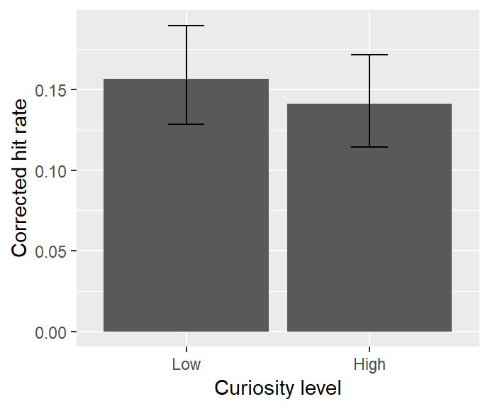

```
##
##  Paired t-test
##
## data:  CorrContextAccuracy by RatingGroup
## t = 0.70587, df = 39, p-value = 0.4845
## alternative hypothesis: true difference in means is not equal to 0
## 95 percent confidence interval:
##  -0.02863053  0.05932498
## sample estimates:
## mean of the differences
##              0.01534722
```

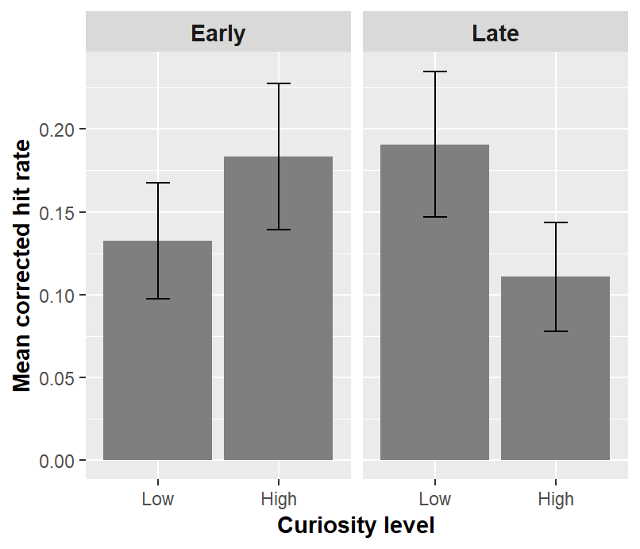

##### 4.2.2.3.2 Stats on it

```
##                  Model df       AIC       BIC   logLik   Test   L.Ratio
## baseline             1  5 -200.7197 -185.3438 105.3598
## curiosityModel       2  6 -199.2095 -180.7585 105.6047 1 vs 2  0.489821
## orderModel           3  7 -197.3688 -175.8426 105.6844 2 vs 3  0.159296
## interactionModel     4  8 -209.4551 -184.8537 112.7275 3 vs 4 14.086254
##                  p-value
## baseline
## curiosityModel    0.4840
## orderModel        0.6898
## interactionModel  0.0002
```

Again, significant interaction.

```r
summary(interactionModel)$tTable
```

```
##                                         Value  Std.Error DF   t-value
## (Intercept)                        0.13259259 0.01947242 78  6.809251
## RatingGroupHigh                    0.05085648 0.02694754 39  1.887240
## ItemOrderTypeLate                  0.05814815 0.02387307 78  2.435721
## RatingGroupHigh:ItemOrderTypeLate -0.13083333 0.03376162 78 -3.875209
##                                        p-value
## (Intercept)                       1.812941e-09
## RatingGroupHigh                   6.658687e-02
## ItemOrderTypeLate                 1.714345e-02
## RatingGroupHigh:ItemOrderTypeLate 2.205382e-04
```

For the early items, the recollection was only marginally better for high curiosity, *p* = 0.067.

##### 4.2.2.3.3 Simple effects in “Early”

```r
t.test(CorrContextAccuracy ~ RatingGroup, data = Curiosity.Recall.Old.Order.CuriosityType.MeanSep[!SubjectNo %in% c(bad.ps.less.strict) & ItemOrderType == "Early"], paired = T)
```

```
##
##  Paired t-test
##
## data:  CorrContextAccuracy by RatingGroup
## t = -1.6853, df = 39, p-value = 0.09992
## alternative hypothesis: true difference in means is not equal to 0
## 95 percent confidence interval:
##  -0.11189471  0.01018175
## sample estimates:
## mean of the differences
##             -0.05085648
```

##### 4.2.2.3.4 Simple effects in “Late”

```r
t.test(ContextAccuracy ~ RatingGroup, data = Curiosity.Recall.Old.Order.CuriosityType.MeanSep[!SubjectNo %in% c(bad.ps.less.strict) & ItemOrderType == "Late"], paired = T)
```

```
##
##  Paired t-test
##
## data:  ContextAccuracy by RatingGroup
## t = 3.356, df = 39, p-value = 0.001773
## alternative hypothesis: true difference in means is not equal to 0
## 95 percent confidence interval:
##  0.03156214 0.12732675
## sample estimates:
## mean of the differences
##              0.07944444
```

#### 4.2.2.4 Linear trend respectivley for High and Low curiosity groups

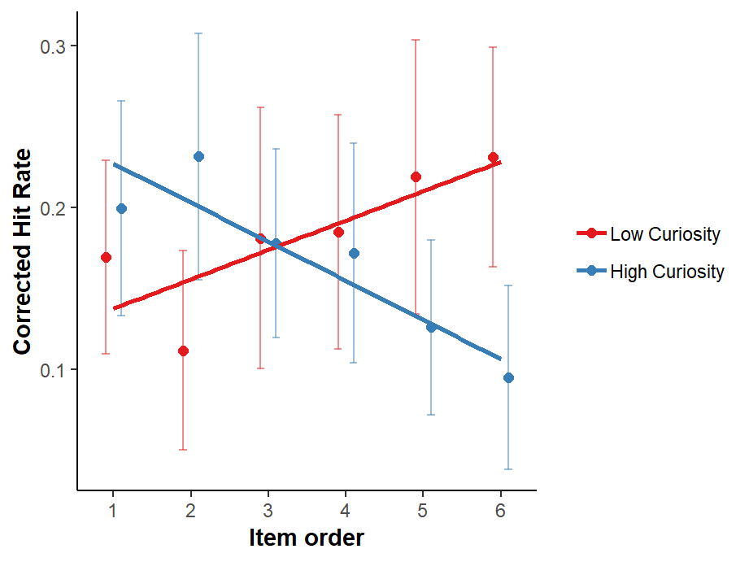

```r
Curiosity.Recall.Old.CuriosityType.MeanSep$ItemOrderCt <- Curiosity.Recall.Old.CuriosityType.MeanSep$ItemOrder - 1

baseline <- lme(CorrContextAccuracy ~ 1, random = ~ 1|SubjectNo/RatingGroup, data = Curiosity.Recall.Old.CuriosityType.MeanSep[!SubjectNo %in% bad.ps.less.strict], method = "ML", control = list(msMaxIter = 500, opt = "optim", msVerbose=FALSE), na.action = na.exclude)

orderModel.linear.1   <- update(baseline,              .~. + ItemOrderCt)
# orderModel.linear.2   <- update(orderModel.linear.1,   random = ~ 1 + ItemOrderCt|SubjectNo/RatingGroup)

curiosityModel        <- update(orderModel.linear.1,   .~. + RatingGroup)
curiosityModel.linear <- update(curiosityModel,        .~. + RatingGroup : ItemOrderCt)

anova(baseline, orderModel.linear.1, curiosityModel, curiosityModel.linear)
```

```
##                       Model df       AIC       BIC   logLik   Test
## baseline                  1  4 -111.5178 -94.82268 59.75891
## orderModel.linear.1       2  5 -109.7969 -88.92801 59.89847 1 vs 2
## curiosityModel            3  6 -108.4733 -83.43056 60.23664 2 vs 3
## curiosityModel.linear     4  7 -120.6526 -91.43606 67.32628 3 vs 4
##                         L.Ratio p-value
## baseline
## orderModel.linear.1    0.279114  0.5973
## curiosityModel         0.676334  0.4109
## curiosityModel.linear 14.179287  0.0002
```

Significant interaction, *p* < 0.001.

```r
summary(curiosityModel.linear)$tTable
```

```
##                                   Value  Std.Error  DF   t-value
## (Intercept)                  0.13760362 0.02438206 398  5.643642
## ItemOrderCt                  0.01816534 0.00791600 398  2.294763
## RatingGroupHigh              0.08986001 0.03392201  39  2.649018
## ItemOrderCt:RatingGroupHigh -0.04232209 0.01119491 398 -3.780474
##                                  p-value
## (Intercept)                 3.167385e-08
## ItemOrderCt                 2.226645e-02
## RatingGroupHigh             1.159532e-02
## ItemOrderCt:RatingGroupHigh 1.805129e-04
```

For the first item, the performance was significantly better for high curiosity, *p* = 0.012.

```r
highModel <- lme(CorrContextAccuracy ~ ItemOrderCt, random = ~ 1|SubjectNo/RatingGroup, data = Curiosity.Recall.Old.CuriosityType.MeanSep[!SubjectNo %in% bad.ps.less.strict & RatingGroup == "High"], method = "ML", control = list(msMaxIter = 500, opt = "optim", msVerbose=FALSE), na.action = na.exclude)
summary(highModel)$tTable
```

```
##                   Value  Std.Error  DF   t-value      p-value
## (Intercept)  0.22746362 0.02314162 199  9.829199 7.750592e-19
## ItemOrderCt -0.02415675 0.00732164 199 -3.299363 1.148130e-03
```

For high curiosity, performance decreased significantly over items, *p* < 0.01.

```r
lowModel <- lme(CorrContextAccuracy ~ ItemOrderCt, random = ~ 1|SubjectNo/RatingGroup, data = Curiosity.Recall.Old.CuriosityType.MeanSep[!SubjectNo %in% bad.ps.less.strict & RatingGroup == "Low"], method = "ML", control = list(msMaxIter = 500, opt = "optim", msVerbose=FALSE), na.action = na.exclude)
summary(lowModel)$tTable
```

```
##                  Value   Std.Error  DF  t-value      p-value
## (Intercept) 0.13760362 0.025610700 199 5.372896 2.153702e-07
## ItemOrderCt 0.01816534 0.008451396 199 2.149390 3.281075e-02
```

For low curiosity, performance increased significantly over items, *p* = 0.033.

# 5 Curiosity and novelty

## 5.1 Testing the effects of curiosity rating and novelty together

Build models with context memory accuracy as $y$ and examine effects of curiosity rating and novelty together by including them into the model separately and then comparing the model fits.

```
##                   Model df       AIC       BIC   logLik   Test   L.Ratio
## baseline.rating       1  4 -136.5280 -122.6727 72.26399
## rating.intercept      2  5 -135.0180 -117.6988 72.50899 1 vs 2 0.4899874
## novelty.model.1       3  6 -134.0557 -113.2727 73.02782 2 vs 3 1.0376709
## interaction.model     4  7 -132.0704 -107.8236 73.03520 3 vs 4 0.0147560
##                   p-value
## baseline.rating
## rating.intercept   0.4839
## novelty.model.1    0.3084
## interaction.model  0.9033
```

### 5.1.1 Check the complete model

```
##                                   Value  Std.Error  DF    t-value
## (Intercept)                 0.235726292 0.03838233 154  6.1415311
## CuriosityRating            -0.010826386 0.01156704 154 -0.9359682
## GroupNovel                  0.048999439 0.10665265  39  0.4594301
## CuriosityRating:GroupNovel -0.002512431 0.02028036 154 -0.1238849
##                                 p-value
## (Intercept)                6.664997e-09
## CuriosityRating            3.507549e-01
## GroupNovel                 6.484761e-01
## CuriosityRating:GroupNovel 9.015679e-01
```

## 5.2 What about the other way around

```
##                   Model df      AIC      BIC    logLik   Test  L.Ratio
## baseline.context      1  3 1484.371 1500.138 -739.1856
## novelty.model.1       2  4 1486.336 1507.359 -739.1681 1 vs 2 0.035068
## rating.model.1        3  5 1484.628 1510.906 -737.3140 2 vs 3 3.708141
## rating.model.2        4 10 1494.397 1546.953 -737.1985 3 vs 4 0.230909
## interaction.model     5 11 1495.838 1553.650 -736.9191 4 vs 5 0.558882
##                   p-value
## baseline.context
## novelty.model.1    0.8515
## rating.model.1     0.0541
## rating.model.2     0.9987
## interaction.model  0.4547
```

## 5.3 Check the collapsed data

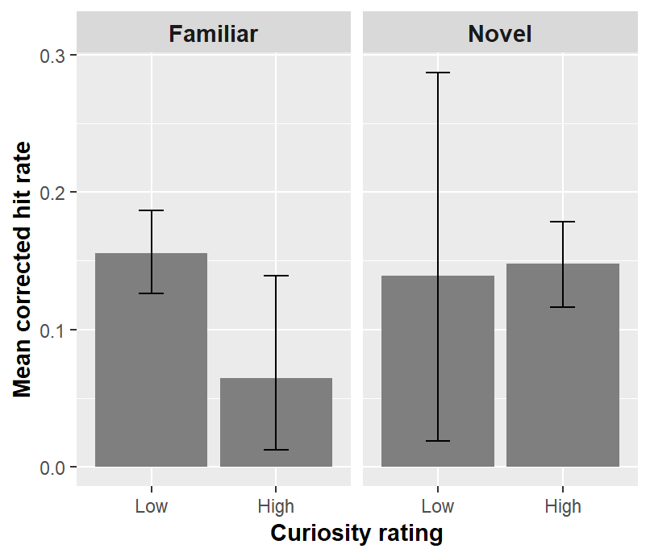

Sample sizes differed hugely between conditions, so hard to compare.

# 6 Curiosity effects in the *Novel* group

## 6.1 Mean accuracy of item memory as a function of curiosity rating

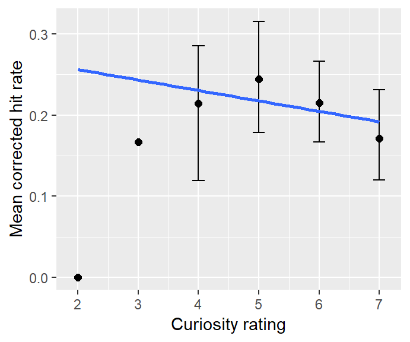